# RforMarineScience_Modulde2_Week3-4

Andreanne Paul-Chowdhury

2026-08-11

# Workshop Overview

This workshop introduces foundational data-wrangling and visualisation techniques in R. The aim is to learn how ecological datasets can be inspected, filtered, transformed, summarised and visualised to identify meaningful biological patterns.

```r
#Workshop 1 - Foundations of Data Science

# Load packages
library(tidyverse)
library(palmerpenguins)
# Exploring the Dataset
# Load the Palmer Penguins dataset
data("penguins")

# View the data structure
glimpse(penguins)
```

```
## Rows: 344
## Columns: 8
## $ species           <fct> Adelie, Adelie, Adelie, Adelie, Adelie, Adelie, Adel…
## $ island            <fct> Torgersen, Torgersen, Torgersen, Torgersen, Torgerse…
## $ bill_length_mm    <dbl> 39.1, 39.5, 40.3, NA, 36.7, 39.3, 38.9, 39.2, 34.1, …
## $ bill_depth_mm     <dbl> 18.7, 17.4, 18.0, NA, 19.3, 20.6, 17.8, 19.6, 18.1, …
## $ flipper_length_mm <int> 181, 186, 195, NA, 193, 190, 181, 195, 193, 190, 186…
## $ body_mass_g       <int> 3750, 3800, 3250, NA, 3450, 3650, 3625, 4675, 3475, …
## $ sex               <fct> male, female, female, NA, female, male, female, male…
## $ year              <int> 2007, 2007, 2007, 2007, 2007, 2007, 2007, 2007, 2007…
```

```r
# View a statistical summary
summary(penguins)
```

```
##       species          island    bill_length_mm  bill_depth_mm
##  Adelie   :152   Biscoe   :168   Min.   :32.10   Min.   :13.10
##  Chinstrap: 68   Dream    :124   1st Qu.:39.23   1st Qu.:15.60
##  Gentoo   :124   Torgersen: 52   Median :44.45   Median :17.30
##                                  Mean   :43.92   Mean   :17.15
##                                  3rd Qu.:48.50   3rd Qu.:18.70
##                                  Max.   :59.60   Max.   :21.50
##                                  NA's   :2       NA's   :2
##  flipper_length_mm  body_mass_g       sex           year
##  Min.   :172.0     Min.   :2700   female:165   Min.   :2007
##  1st Qu.:190.0     1st Qu.:3550   male  :168   1st Qu.:2007
##  Median :197.0     Median :4050   NA's  : 11   Median :2008
##  Mean   :200.9     Mean   :4202                Mean   :2008
##  3rd Qu.:213.0     3rd Qu.:4750                3rd Qu.:2009
##  Max.   :231.0     Max.   :6300                Max.   :2009
##  NA's   :2         NA's   :2
```

```r
## Selecting Variables
# Select morphological variables
morphology_metrics <- penguins |>
  select(
    species,
    island,
    bill_length_mm,
    bill_depth_mm,
    body_mass_g
  )

glimpse(morphology_metrics)
```

```
## Rows: 344
## Columns: 5
## $ species        <fct> Adelie, Adelie, Adelie, Adelie, Adelie, Adelie, Adelie,…
## $ island         <fct> Torgersen, Torgersen, Torgersen, Torgersen, Torgersen, …
## $ bill_length_mm <dbl> 39.1, 39.5, 40.3, NA, 36.7, 39.3, 38.9, 39.2, 34.1, 42.…
## $ bill_depth_mm  <dbl> 18.7, 17.4, 18.0, NA, 19.3, 20.6, 17.8, 19.6, 18.1, 20.…
## $ body_mass_g    <int> 3750, 3800, 3250, NA, 3450, 3650, 3625, 4675, 3475, 425…
```

```r
## Filtering Observations
# Keep only Adelie penguins
adelie_penguins <- penguins |>
  filter(species == "Adelie")

# Keep penguins heavier than 4500 g
heavy_penguins <- penguins |>
  filter(body_mass_g > 4500)

# Keep Gentoo penguins sampled on Biscoe Island
biscoe_gentoo <- penguins |>
  filter(
    species == "Gentoo",
    island == "Biscoe"
  )

## Arranging Observations
# Smallest penguins first
lightest_first <- penguins |>
  arrange(body_mass_g)

# Heaviest penguins first
heaviest_first <- penguins |>
  arrange(desc(body_mass_g))

head(heaviest_first)
```

```
## # A tibble: 6 × 8
##   species island bill_length_mm bill_depth_mm flipper_length_mm body_mass_g
##   <fct>   <fct>           <dbl>         <dbl>             <int>       <int>
## 1 Gentoo  Biscoe           49.2          15.2               221        6300
## 2 Gentoo  Biscoe           59.6          17                 230        6050
## 3 Gentoo  Biscoe           51.1          16.3               220        6000
## 4 Gentoo  Biscoe           48.8          16.2               222        6000
## 5 Gentoo  Biscoe           45.2          16.4               223        5950
## 6 Gentoo  Biscoe           49.8          15.9               229        5950
## # ℹ 2 more variables: sex <fct>, year <int>
```

```r
## Creating New Variables
penguin_ratios <- penguins |>
  mutate(
    body_mass_kg = body_mass_g / 1000,
    bill_ratio = bill_length_mm / bill_depth_mm
  )

glimpse(penguin_ratios)
```

```
## Rows: 344
## Columns: 10
## $ species           <fct> Adelie, Adelie, Adelie, Adelie, Adelie, Adelie, Adel…
## $ island            <fct> Torgersen, Torgersen, Torgersen, Torgersen, Torgerse…
## $ bill_length_mm    <dbl> 39.1, 39.5, 40.3, NA, 36.7, 39.3, 38.9, 39.2, 34.1, …
## $ bill_depth_mm     <dbl> 18.7, 17.4, 18.0, NA, 19.3, 20.6, 17.8, 19.6, 18.1, …
## $ flipper_length_mm <int> 181, 186, 195, NA, 193, 190, 181, 195, 193, 190, 186…
## $ body_mass_g       <int> 3750, 3800, 3250, NA, 3450, 3650, 3625, 4675, 3475, …
## $ sex               <fct> male, female, female, NA, female, male, female, male…
## $ year              <int> 2007, 2007, 2007, 2007, 2007, 2007, 2007, 2007, 2007…
## $ body_mass_kg      <dbl> 3.750, 3.800, 3.250, NA, 3.450, 3.650, 3.625, 4.675,…
## $ bill_ratio        <dbl> 2.090909, 2.270115, 2.238889, NA, 1.901554, 1.907767…
```

```r
# Ecological Summaries
#penguins |>
#  group_by(species) |>
#  summarise(
#    mean_mass_g = mean(body_mass_g)
#  )
##NA values
penguins |>
  group_by(species) |>
  summarise(
    mean_mass_g = mean(body_mass_g, na.rm = TRUE)
  )
```

```
## # A tibble: 3 × 2
##   species   mean_mass_g
##   <fct>           <dbl>
## 1 Adelie          3701.
## 2 Chinstrap       3733.
## 3 Gentoo          5076.
```

```r
## Mean Body Mass by Species and Island
body_mass_summary <- penguins |>
  group_by(species, island) |>
  summarise(
    mean_body_mass_g = mean(body_mass_g, na.rm = TRUE),
    .groups = "drop"
  )

body_mass_summary
```

```
## # A tibble: 5 × 3
##   species   island    mean_body_mass_g
##   <fct>     <fct>                <dbl>
## 1 Adelie    Biscoe               3710.
## 2 Adelie    Dream                3688.
## 3 Adelie    Torgersen            3706.
## 4 Chinstrap Dream                3733.
## 5 Gentoo    Biscoe               5076.
```

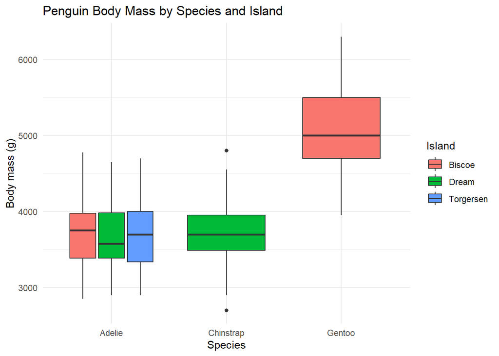

```r
# Data Visualisation
body_mass_plot <- penguins |>
  drop_na(body_mass_g) |>
  ggplot(
    aes(
      x = species,
      y = body_mass_g,
      fill = island
    )
  ) +
  geom_boxplot() +
  labs(
    title = "Penguin Body Mass by Species and Island",
    x = "Species",
    y = "Body mass (g)",
    fill = "Island"
  ) +
  theme_minimal()

body_mass_plot
```

```r
#Save outputs
ggsave(
  filename = "outputs/workshop1_body_mass_plot.png",
  plot = body_mass_plot,
  width = 8,
  height = 6,
  dpi = 300
)

write_csv(
  body_mass_summary,
  "outputs/workshop1_body_mass_summary.csv"
)
```

```r
# Final Morphological Summary
mass_summary_final <- penguins |>
  group_by(species, island) |>
  summarise(
    n = sum(!is.na(body_mass_g)),
    mean_mass_g = mean(body_mass_g, na.rm = TRUE),
    sd_mass_g = sd(body_mass_g, na.rm = TRUE),
    se_mass_g = sd_mass_g / sqrt(n),
    .groups = "drop"
  )

mass_summary_final
```

```
## # A tibble: 5 × 6
##   species   island        n mean_mass_g sd_mass_g se_mass_g
##   <fct>     <fct>     <int>       <dbl>     <dbl>     <dbl>
## 1 Adelie    Biscoe       44       3710.      488.      73.5
## 2 Adelie    Dream        56       3688.      455.      60.8
## 3 Adelie    Torgersen    51       3706.      445.      62.3
## 4 Chinstrap Dream        68       3733.      384.      46.6
## 5 Gentoo    Biscoe      123       5076.      504.      45.5
```

```r
knitr::kable(
  mass_summary_final,
  digits = 2,
  caption = "Summary of penguin body mass by species and island."
)
```

Summary of penguin body mass by species and island.

| species | island | n | mean_mass_g | sd_mass_g | se_mass_g |
| --- | --- | --- | --- | --- | --- |
| Adelie | Biscoe | 44 | 3709.66 | 487.73 | 73.53 |
| Adelie | Dream | 56 | 3688.39 | 455.15 | 60.82 |
| Adelie | Torgersen | 51 | 3706.37 | 445.11 | 62.33 |
| Chinstrap | Dream | 68 | 3733.09 | 384.34 | 46.61 |
| Gentoo | Biscoe | 123 | 5076.02 | 504.12 | 45.45 |

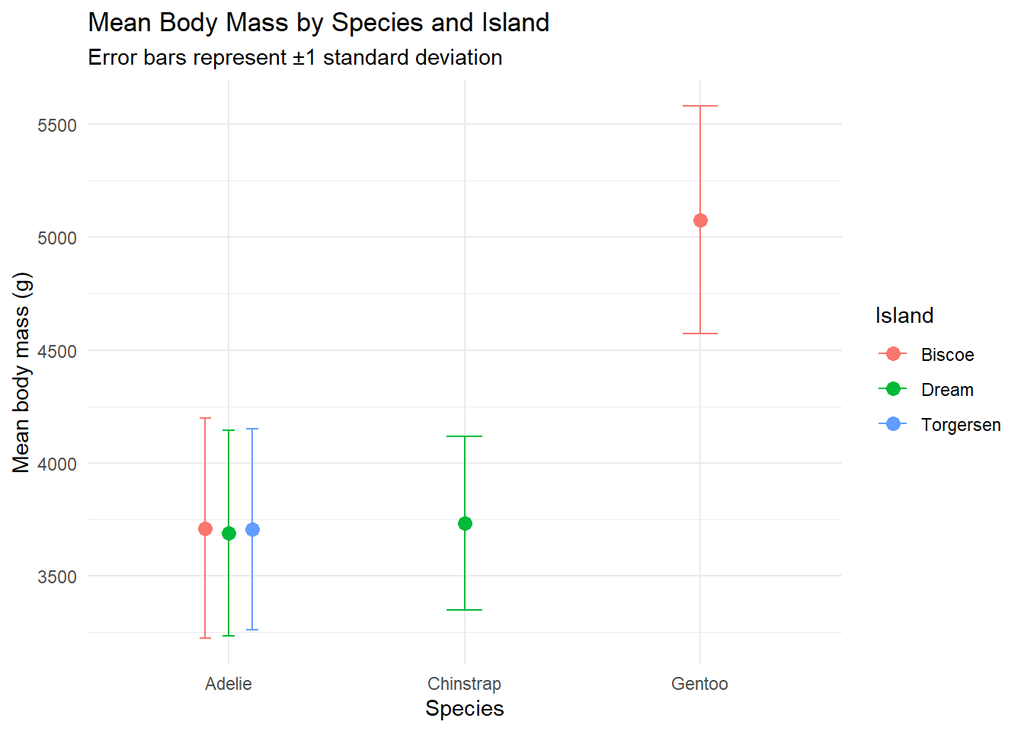

```r
## Mean Body Mass and Variation
mass_compare_plot <- mass_summary_final |>
  ggplot(
    aes(
      x = species,
      y = mean_mass_g,
      colour = island
    )
  ) +
  geom_point(
    size = 3,
    position = position_dodge(width = 0.3)
  ) +
  geom_errorbar(
    aes(
      ymin = mean_mass_g - sd_mass_g,
      ymax = mean_mass_g + sd_mass_g
    ),
    width = 0.15,
    position = position_dodge(width = 0.3)
  ) +
  labs(
    title = "Mean Body Mass by Species and Island",
    subtitle = "Error bars represent ±1 standard deviation",
    x = "Species",
    y = "Mean body mass (g)",
    colour = "Island"
  ) +
  theme_minimal()

mass_compare_plot
```

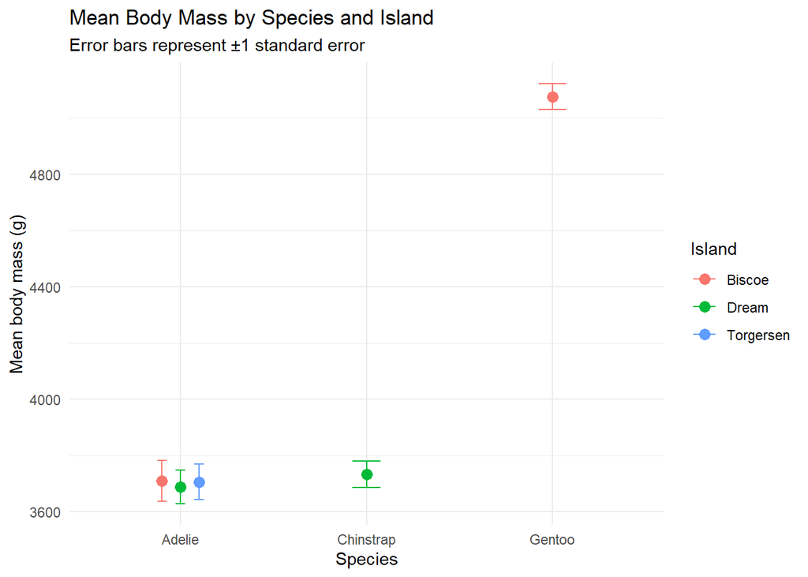

```r
## Comparing Standard Deviation and Standard Error
mass_se_plot <- mass_summary_final |>
  ggplot(
    aes(
      x = species,
      y = mean_mass_g,
      colour = island
    )
  ) +
  geom_point(
    size = 3,
    position = position_dodge(width = 0.3)
  ) +
  geom_errorbar(
    aes(
      ymin = mean_mass_g - se_mass_g,
      ymax = mean_mass_g + se_mass_g
    ),
    width = 0.15,
    position = position_dodge(width = 0.3)
  ) +
  labs(
    title = "Mean Body Mass by Species and Island",
    subtitle = "Error bars represent ±1 standard error",
    x = "Species",
    y = "Mean body mass (g)",
    colour = "Island"
  ) +
  theme_minimal()

mass_se_plot
```

### Interpretation ####The grouped analysis demonstrates how individual morphological observations can be transformed into population-level summaries. Comparing mean body mass and variation among species and islands makes differences between biological groups easier to identify than examining the raw observations alone. The exercise also demonstrates that the choice of uncertainty measure matters: standard deviation describes variation among individuals, whereas standard error describes the precision of the estimated group mean.

```r
ggsave(
  filename = "outputs/workshop1_mass_summary_plot.png",
  plot = mass_compare_plot,
  width = 8,
  height = 6,
  dpi = 300
)
write_csv(
  mass_summary_final,
  "outputs/workshop1_mass_summary.csv"
)
```

#Workshop 2 # Workshop Overview

This workshop develops advanced data-wrangling skills for working with complex and messy ecological datasets. The workflow focuses on tidy data, reshaping datasets, standardising text and dates, joining related datasets, managing missing values and explicit zeros, and integrating multiple sources of biological and environmental data.

```r
# Load packages
library(tidyverse)
library(palmerpenguins)
library(readxl)
library(lubridate)
library(here)
# Tidy Data
##tidy data aren't necessarily prettier, they're structured so R can analyse them efficiently.

# Reshaping Data

## Pivoting Longer
data("penguins")

penguins_long <- penguins |>
  pivot_longer(
    cols = c(
      bill_length_mm,
      bill_depth_mm,
      flipper_length_mm,
      body_mass_g
    ),
    names_to = "measurement_type",
    values_to = "value"
  )

glimpse(penguins_long)
```

```
## Rows: 1,376
## Columns: 6
## $ species          <fct> Adelie, Adelie, Adelie, Adelie, Adelie, Adelie, Adeli…
## $ island           <fct> Torgersen, Torgersen, Torgersen, Torgersen, Torgersen…
## $ sex              <fct> male, male, male, male, female, female, female, femal…
## $ year             <int> 2007, 2007, 2007, 2007, 2007, 2007, 2007, 2007, 2007,…
## $ measurement_type <chr> "bill_length_mm", "bill_depth_mm", "flipper_length_mm…
## $ value            <dbl> 39.1, 18.7, 181.0, 3750.0, 39.5, 17.4, 186.0, 3800.0,…
```

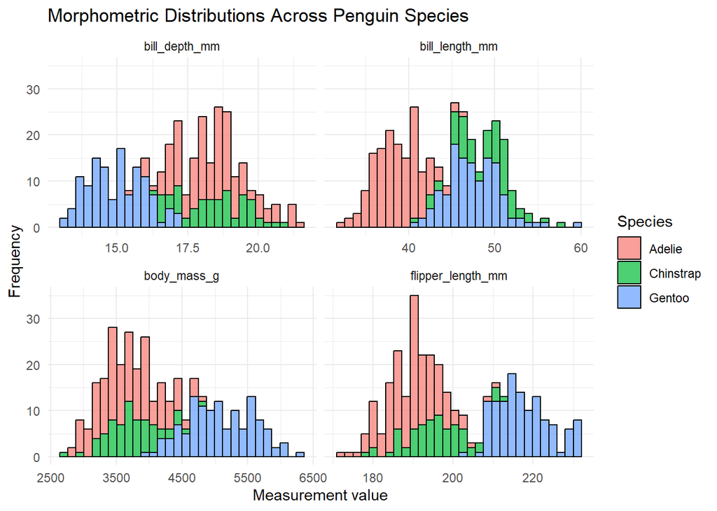

```r
penguins_long |>
  drop_na(value) |>
  ggplot(
    aes(
      x = value,
      fill = species
    )
  ) +
  geom_histogram(
    bins = 30,
    alpha = 0.7,
    colour = "black"
  ) +
  facet_wrap(
    ~ measurement_type,
    scales = "free_x"
  ) +
  theme_minimal() +
  labs(
    title = "Morphometric Distributions Across Penguin Species",
    x = "Measurement value",
    y = "Frequency",
    fill = "Species"
  )
```

```r
## Pivoting Wider
mass_summary <- penguins |>
  drop_na(body_mass_g) |>
  group_by(species, island) |>
  summarise(
    mean_mass = mean(body_mass_g),
    .groups = "drop"
  )

mass_summary
```

```
## # A tibble: 5 × 3
##   species   island    mean_mass
##   <fct>     <fct>         <dbl>
## 1 Adelie    Biscoe        3710.
## 2 Adelie    Dream         3688.
## 3 Adelie    Torgersen     3706.
## 4 Chinstrap Dream         3733.
## 5 Gentoo    Biscoe        5076.
```

```r
mass_matrix <- mass_summary |>
  pivot_wider(
    names_from = island,
    values_from = mean_mass
  )

mass_matrix
```

```
## # A tibble: 3 × 4
##   species   Biscoe Dream Torgersen
##   <fct>      <dbl> <dbl>     <dbl>
## 1 Adelie     3710. 3688.     3706.
## 2 Chinstrap    NA  3733.       NA
## 3 Gentoo     5076.   NA        NA
```

```r
# Cleaning Text and Dates
messy_sites <- tibble(
  site_id = c(
    " Nelly Bay",
    "nelly_bay",
    "NELLY BAY",
    " Geoffrey_Bay ",
    "geoffrey bay"
  )
)

clean_sites <- messy_sites |>
  mutate(
    site_clean = str_to_lower(site_id),
    site_clean = str_trim(site_clean),
    site_clean = str_replace_all(
      site_clean,
      pattern = " ",
      replacement = "_"
    )
  )

clean_sites
```

```
## # A tibble: 5 × 2
##   site_id          site_clean
##   <chr>            <chr>
## 1 " Nelly Bay"     nelly_bay
## 2 "nelly_bay"      nelly_bay
## 3 "NELLY BAY"      nelly_bay
## 4 " Geoffrey_Bay " geoffrey_bay
## 5 "geoffrey bay"   geoffrey_bay
```

```r
date_1 <- dmy("25/12/2026")
date_2 <- ymd("2026-12-25")

date_1
```

```
## [1] "2026-12-25"
```

```r
date_2
```

```
## [1] "2026-12-25"
```

```r
date_1 == date_2
```

```
## [1] TRUE
```

```r
sensor_data <- tibble(
  raw_time = c(
    "14-05-2026 08:30:00",
    "14-05-2026 08:45:00",
    "14-05-2026 09:00:00"
  ),
  temperature = c(
    24.5,
    24.6,
    24.4
  )
)

sensor_clean <- sensor_data |>
  mutate(
    true_time = dmy_hms(raw_time)
  )

sensor_clean
```

```
## # A tibble: 3 × 3
##   raw_time            temperature true_time
##   <chr>                     <dbl> <dttm>
## 1 14-05-2026 08:30:00        24.5 2026-05-14 08:30:00
## 2 14-05-2026 08:45:00        24.6 2026-05-14 08:45:00
## 3 14-05-2026 09:00:00        24.4 2026-05-14 09:00:00
```

```r
#Practise a relational join
# Relational Data and Joins
island_metadata <- tibble(
  island_name = c(
    " biscoe",
    "Dream ",
    "Torgersen"
  ),
  station_install = c(
    "15/01/2003",
    "22-03-2004",
    "05/11/2001"
  ),
  latitude = c(
    -64.81,
    -64.73,
    -64.76
  )
)

island_metadata
```

```
## # A tibble: 3 × 3
##   island_name station_install latitude
##   <chr>       <chr>              <dbl>
## 1 " biscoe"   15/01/2003         -64.8
## 2 "Dream "    22-03-2004         -64.7
## 3 "Torgersen" 05/11/2001         -64.8
```

```r
#Clean it
clean_metadata <- island_metadata |>
  mutate(
    island_name = str_trim(island_name),
    island_name = str_to_title(island_name),
    station_install = dmy(station_install)
  )

clean_metadata
```

```
## # A tibble: 3 × 3
##   island_name station_install latitude
##   <chr>       <date>             <dbl>
## 1 Biscoe      2003-01-15         -64.8
## 2 Dream       2004-03-22         -64.7
## 3 Torgersen   2001-11-05         -64.8
```

```r
#Join with penguins
penguins_spatial <- penguins |>
  left_join(
    clean_metadata,
    by = join_by(island == island_name)
  )

glimpse(penguins_spatial)
```

```
## Rows: 344
## Columns: 10
## $ species           <fct> Adelie, Adelie, Adelie, Adelie, Adelie, Adelie, Adel…
## $ island            <chr> "Torgersen", "Torgersen", "Torgersen", "Torgersen", …
## $ bill_length_mm    <dbl> 39.1, 39.5, 40.3, NA, 36.7, 39.3, 38.9, 39.2, 34.1, …
## $ bill_depth_mm     <dbl> 18.7, 17.4, 18.0, NA, 19.3, 20.6, 17.8, 19.6, 18.1, …
## $ flipper_length_mm <int> 181, 186, 195, NA, 193, 190, 181, 195, 193, 190, 186…
## $ body_mass_g       <int> 3750, 3800, 3250, NA, 3450, 3650, 3625, 4675, 3475, …
## $ sex               <fct> male, female, female, NA, female, male, female, male…
## $ year              <int> 2007, 2007, 2007, 2007, 2007, 2007, 2007, 2007, 2007…
## $ station_install   <date> 2001-11-05, 2001-11-05, 2001-11-05, 2001-11-05, 200…
## $ latitude          <dbl> -64.76, -64.76, -64.76, -64.76, -64.76, -64.76, -64.…
```

```r
#Why anti_join() matters
penguins |>
  anti_join(
    clean_metadata,
    by = join_by(island == island_name)
  )
```

```
## # A tibble: 0 × 8
## # ℹ 8 variables: species <fct>, island <fct>, bill_length_mm <dbl>,
## #   bill_depth_mm <dbl>, flipper_length_mm <int>, body_mass_g <int>, sex <fct>,
## #   year <int>
```

```r
# Missing Values and Ecological Zeros
logger_data <- tibble(
  depth_m = c(10, 20, 30, 40),
  temp_c = c(24.5, 24.1, -999, 23.5)
)
logger_clean <- logger_data |>
  mutate(
    temp_c = na_if(temp_c, -999)
  )

logger_clean
```

```
## # A tibble: 4 × 2
##   depth_m temp_c
##     <dbl>  <dbl>
## 1      10   24.5
## 2      20   24.1
## 3      30   NA
## 4      40   23.5
```

```r
#Understand ecological zeros
raw_catch <- tibble(
  site = c(
    "Reef_1",
    "Reef_1",
    "Reef_2"
  ),
  species = c(
    "Pmaculatus",
    "Pleopardus",
    "Pmaculatus"
  ),
  count = c(
    5,
    2,
    8
  )
)

full_catch_matrix <- raw_catch |>
  complete(
    site,
    species,
    fill = list(count = 0)
  )

full_catch_matrix
```

```
## # A tibble: 4 × 3
##   site   species    count
##   <chr>  <chr>      <dbl>
## 1 Reef_1 Pleopardus     2
## 2 Reef_1 Pmaculatus     5
## 3 Reef_2 Pleopardus     0
## 4 Reef_2 Pmaculatus     8
```

```r
#Data rescue mission

# Estuary Fish Survey Data Rescue Mission

## Inspecting the Raw Data
list.files("data")
```

```
## character(0)
```

```r
catch_sheets <- excel_sheets(
  here("data", "estuary_catch_log.xlsx")
)

catch_sheets
```

```
## [1] "Lower_ross" "Mid_Ross "  "ROSS MOUTH" "Upper Ross"
```

```r
catch_test <- read_excel(
  here("data", "estuary_catch_log.xlsx"),
  sheet = catch_sheets[1]
)

glimpse(catch_test)
```

```
## Rows: 104
## Columns: 4
## $ site    <chr> "Lower_ross", "Lower_ross", "Lower_ross", "Lower_ross", "Lower…
## $ date    <dttm> 2026-05-01, 2026-05-01, 2026-05-01, 2026-05-01, 2026-05-02, 2…
## $ species <chr> "barramundi", "MANGROVE JACK", "bream", "flathead", "barramund…
## $ count   <dbl> 6, 3, 4, 2, 1, 1, 3, 3, 2, 3, 1, 8, 4, 1, 1, 2, 1, 2, 4, 2, 2,…
```

```r
head(catch_test)
```

```
## # A tibble: 6 × 4
##   site       date                species       count
##   <chr>      <dttm>              <chr>         <dbl>
## 1 Lower_ross 2026-05-01 00:00:00 barramundi        6
## 2 Lower_ross 2026-05-01 00:00:00 MANGROVE JACK     3
## 3 Lower_ross 2026-05-01 00:00:00 bream             4
## 4 Lower_ross 2026-05-01 00:00:00 flathead          2
## 5 Lower_ross 2026-05-02 00:00:00 barramundi        1
## 6 Lower_ross 2026-05-02 00:00:00 MANGROVE JACK     1
```

```r
#Inspect all other 3 files
metadata_raw <- read_csv(
  here("data", "estuary_metadata.csv")
)
sonde_raw <- read_csv(
  here("data", "estuary_sonde_data.csv")
)
species_dictionary_raw <- read_csv(
  here("data", "species_dictionary.csv")
)
# Data Rescue Mission

## Checking Variable Names
# Catch data - first Excel sheet
names(catch_test)
```

```
## [1] "site"    "date"    "species" "count"
```

```r
# Site metadata
names(metadata_raw)
```

```
## [1] "site_name" "lat"       "lon"       "zone"
```

```r
# Water-quality sonde data
names(sonde_raw)
```

```
## [1] "site"        "timestamp"   "temperature" "salinity"    "turbidity"
```

```r
# Species dictionary
#names(species_dictionary)

#Something was wrong dont know what but had to load file again
list.files("data")
```

```
## character(0)
```

```r
species_dictionary_raw <- read_csv(
  here("data", "species_dictionary.csv")
)
names(species_dictionary_raw)
```

```
## [1] "common_name"     "scientific_name"
```

```r
glimpse(species_dictionary_raw)
```

```
## Rows: 4
## Columns: 2
## $ common_name     <chr> "barramundi", "mangrove_jack", "bream", "flathead"
## $ scientific_name <chr> "Lates calcarifer", "Lutjanus argentimaculatus", "Acan…
```

```r
## Phase 1: Ingestion and Decontamination

### Combining Catch Records
catch_raw_all <- map_dfr(
  catch_sheets,
  ~ read_excel(
    here("data", "estuary_catch_log.xlsx"),
    sheet = .x
  )
)

glimpse(catch_raw_all)
```

```
## Rows: 427
## Columns: 4
## $ site    <chr> "Lower_ross", "Lower_ross", "Lower_ross", "Lower_ross", "Lower…
## $ date    <dttm> 2026-05-01, 2026-05-01, 2026-05-01, 2026-05-01, 2026-05-02, 2…
## $ species <chr> "barramundi", "MANGROVE JACK", "bream", "flathead", "barramund…
## $ count   <dbl> 6, 3, 4, 2, 1, 1, 3, 3, 2, 3, 1, 8, 4, 1, 1, 2, 1, 2, 4, 2, 2,…
```

```r
nrow(catch_raw_all)
```

```
## [1] 427
```

```r
distinct(catch_raw_all, site)
```

```
## # A tibble: 4 × 1
##   site
##   <chr>
## 1 Lower_ross
## 2 Mid_Ross
## 3 ROSS MOUTH
## 4 Upper Ross
```

```r
#Standardise the catch data

catch_clean <- catch_raw_all |>
  mutate(
    # Clean site names
    site = str_squish(site),
    site = str_to_lower(site),
    site = str_replace_all(site, "[^a-z0-9]+", "_"),

    # Clean species names
    species = str_squish(species),
    species = str_to_lower(species),
    species = str_replace_all(species, "[^a-z0-9]+", "_")
  )

glimpse(catch_clean)
```

```
## Rows: 427
## Columns: 4
## $ site    <chr> "lower_ross", "lower_ross", "lower_ross", "lower_ross", "lower…
## $ date    <dttm> 2026-05-01, 2026-05-01, 2026-05-01, 2026-05-01, 2026-05-02, 2…
## $ species <chr> "barramundi", "mangrove_jack", "bream", "flathead", "barramund…
## $ count   <dbl> 6, 3, 4, 2, 1, 1, 3, 3, 2, 3, 1, 8, 4, 1, 1, 2, 1, 2, 4, 2, 2,…
```

```r
distinct(catch_clean, site)
```

```
## # A tibble: 4 × 1
##   site
##   <chr>
## 1 lower_ross
## 2 mid_ross
## 3 ross_mouth
## 4 upper_ross
```

```r
distinct(catch_clean, species)
```

```
## # A tibble: 4 × 1
##   species
##   <chr>
## 1 barramundi
## 2 mangrove_jack
## 3 bream
## 4 flathead
```

```r
#Clean the site metadata
metadata_clean <- metadata_raw |>
  mutate(
    site_name = str_squish(site_name),
    site_name = str_to_lower(site_name),
    site_name = str_replace_all(
      site_name,
      "[^a-z0-9]+",
      "_"
    )
  ) |>
  rename(
    site = site_name
  )

metadata_clean
```

```
## # A tibble: 4 × 4
##   site         lat   lon zone
##   <chr>      <dbl> <dbl> <chr>
## 1 upper_ross -19.3  147. Upstream
## 2 mid_ross   -19.3  147. Middle
## 3 lower_ross -19.3  147. Downstream
## 4 ross_mouth -19.2  147. Marine
```

```r
distinct(metadata_clean, site)
```

```
## # A tibble: 4 × 1
##   site
##   <chr>
## 1 upper_ross
## 2 mid_ross
## 3 lower_ross
## 4 ross_mouth
```

```r
#Clean the species dictionary
species_dictionary_clean <- species_dictionary_raw |>
  mutate(
    common_name = str_squish(common_name),
    common_name = str_to_lower(common_name),
    common_name = str_replace_all(
      common_name,
      "[^a-z0-9]+",
      "_"
    )
  )

species_dictionary_clean
```

```
## # A tibble: 4 × 2
##   common_name   scientific_name
##   <chr>         <chr>
## 1 barramundi    Lates calcarifer
## 2 mangrove_jack Lutjanus argentimaculatus
## 3 bream         Acanthopagrus spp.
## 4 flathead      Platycephalus spp.
```

```r
#Clean the sonde data
sonde_clean <- sonde_raw |>
  mutate(
    # Standardise site names
    site = str_squish(site),
    site = str_to_lower(site),
    site = str_replace_all(
      site,
      "[^a-z0-9]+",
      "_"
    ),

    # Convert timestamp text into real date-time data
    timestamp = dmy_hms(timestamp),

    # Convert sensor failure code to genuine missing data
    turbidity = na_if(turbidity, -999.0)
  )
glimpse(sonde_clean)
```

```
## Rows: 11,520
## Columns: 5
## $ site        <chr> "upper_ross", "mid_ross", "lower_ross", "ross_mouth", "upp…
## $ timestamp   <dttm> NA, NA, NA, NA, NA, NA, NA, NA, NA, NA, NA, NA, NA, NA, N…
## $ temperature <dbl> 23.71379, 24.13302, 24.23558, 24.64147, 26.06955, 24.62576…
## $ salinity    <dbl> 4.054812, 15.742962, 28.934938, 33.891350, 3.962750, 12.05…
## $ turbidity   <dbl> 6.489046, 49.216967, 48.135752, 49.811493, 25.184739, 34.8…
```

```r
#Check the -999 gone
sum(sonde_clean$turbidity == -999, na.rm = TRUE)
```

```
## [1] 0
```

```r
sum(is.na(sonde_clean$turbidity))
```

```
## [1] 567
```

```r
#Check if data sets will join
catch_clean |>
  distinct(site) |>
  anti_join(
    metadata_clean |>
      distinct(site),
    by = "site"
  )
```

```
## # A tibble: 0 × 1
## # ℹ 1 variable: site <chr>
```

```r
## Phase 2: Relational Architecture

### Daily Water Quality Summary

sonde_daily <- sonde_clean |>
  mutate(
    date = as.Date(floor_date(timestamp, unit = "day"))
  ) |>
  group_by(site, date) |>
  summarise(
    mean_temperature = mean(temperature, na.rm = TRUE),
    mean_salinity = mean(salinity, na.rm = TRUE),
    .groups = "drop"
  )

sonde_daily
```

```
## # A tibble: 4 × 4
##   site       date   mean_temperature mean_salinity
##   <chr>      <date>            <dbl>         <dbl>
## 1 lower_ross NA                 24.0         28.0
## 2 mid_ross   NA                 24.0         14.9
## 3 ross_mouth NA                 24.0         34.0
## 4 upper_ross NA                 24.0          4.95
```

```r
glimpse(sonde_daily)
```

```
## Rows: 4
## Columns: 4
## $ site             <chr> "lower_ross", "mid_ross", "ross_mouth", "upper_ross"
## $ date             <date> NA, NA, NA, NA
## $ mean_temperature <dbl> 24.00799, 24.01839, 23.95639, 24.00427
## $ mean_salinity    <dbl> 27.966914, 14.912216, 34.021828, 4.946526
```

```r
head(sonde_daily)
```

```
## # A tibble: 4 × 4
##   site       date   mean_temperature mean_salinity
##   <chr>      <date>            <dbl>         <dbl>
## 1 lower_ross NA                 24.0         28.0
## 2 mid_ross   NA                 24.0         14.9
## 3 ross_mouth NA                 24.0         34.0
## 4 upper_ross NA                 24.0          4.95
```

```r
distinct(sonde_daily, site)
```

```
## # A tibble: 4 × 1
##   site
##   <chr>
## 1 lower_ross
## 2 mid_ross
## 3 ross_mouth
## 4 upper_ross
```

```r
#Check catch date format
class(catch_clean$date)
```

```
## [1] "POSIXct" "POSIXt"
```

```r
class(sonde_daily$date)
```

```
## [1] "Date"
```

```r
catch_clean <- catch_clean |>
  mutate(
    date = as.Date(date)
  )
class(catch_clean$date)
```

```
## [1] "Date"
```

```r
#Translate common names to scientific names
catch_taxonomy <- catch_clean |>
  left_join(
    species_dictionary_clean,
    by = c("species" = "common_name")
  )

glimpse(catch_taxonomy)
```

```
## Rows: 427
## Columns: 5
## $ site            <chr> "lower_ross", "lower_ross", "lower_ross", "lower_ross"…
## $ date            <date> 2026-05-01, 2026-05-01, 2026-05-01, 2026-05-01, 2026-…
## $ species         <chr> "barramundi", "mangrove_jack", "bream", "flathead", "b…
## $ count           <dbl> 6, 3, 4, 2, 1, 1, 3, 3, 2, 3, 1, 8, 4, 1, 1, 2, 1, 2, …
## $ scientific_name <chr> "Lates calcarifer", "Lutjanus argentimaculatus", "Acan…
```

```r
distinct(
  catch_taxonomy,
  species,
  scientific_name
)
```

```
## # A tibble: 4 × 2
##   species       scientific_name
##   <chr>         <chr>
## 1 barramundi    Lates calcarifer
## 2 mangrove_jack Lutjanus argentimaculatus
## 3 bream         Acanthopagrus spp.
## 4 flathead      Platycephalus spp.
```

```r
#Check that the toxonomy join worked
sum(is.na(catch_taxonomy$scientific_name))
```

```
## [1] 0
```

```r
#Join the spatial metadata
catch_spatial <- catch_taxonomy |>
  left_join(
    metadata_clean,
    by = "site"
  )

glimpse(catch_spatial)
```

```
## Rows: 427
## Columns: 8
## $ site            <chr> "lower_ross", "lower_ross", "lower_ross", "lower_ross"…
## $ date            <date> 2026-05-01, 2026-05-01, 2026-05-01, 2026-05-01, 2026-…
## $ species         <chr> "barramundi", "mangrove_jack", "bream", "flathead", "b…
## $ count           <dbl> 6, 3, 4, 2, 1, 1, 3, 3, 2, 3, 1, 8, 4, 1, 1, 2, 1, 2, …
## $ scientific_name <chr> "Lates calcarifer", "Lutjanus argentimaculatus", "Acan…
## $ lat             <dbl> -19.26, -19.26, -19.26, -19.26, -19.26, -19.26, -19.26…
## $ lon             <dbl> 146.81, 146.81, 146.81, 146.81, 146.81, 146.81, 146.81…
## $ zone            <chr> "Downstream", "Downstream", "Downstream", "Downstream"…
```

```r
sum(is.na(catch_spatial$zone))
```

```
## [1] 0
```

```r
#Join daily water-qualityd data
master_data <- catch_spatial |>
  left_join(
    sonde_daily,
    by = c("site", "date")
  )

glimpse(master_data)
```

```
## Rows: 427
## Columns: 10
## $ site             <chr> "lower_ross", "lower_ross", "lower_ross", "lower_ross…
## $ date             <date> 2026-05-01, 2026-05-01, 2026-05-01, 2026-05-01, 2026…
## $ species          <chr> "barramundi", "mangrove_jack", "bream", "flathead", "…
## $ count            <dbl> 6, 3, 4, 2, 1, 1, 3, 3, 2, 3, 1, 8, 4, 1, 1, 2, 1, 2,…
## $ scientific_name  <chr> "Lates calcarifer", "Lutjanus argentimaculatus", "Aca…
## $ lat              <dbl> -19.26, -19.26, -19.26, -19.26, -19.26, -19.26, -19.2…
## $ lon              <dbl> 146.81, 146.81, 146.81, 146.81, 146.81, 146.81, 146.8…
## $ zone             <chr> "Downstream", "Downstream", "Downstream", "Downstream…
## $ mean_temperature <dbl> NA, NA, NA, NA, NA, NA, NA, NA, NA, NA, NA, NA, NA, N…
## $ mean_salinity    <dbl> NA, NA, NA, NA, NA, NA, NA, NA, NA, NA, NA, NA, NA, N…
```

```r
#Check the Join
sum(is.na(master_data$zone))
```

```
## [1] 0
```

```r
sum(is.na(master_data$scientific_name))
```

```
## [1] 0
```

```r
sum(is.na(master_data$mean_salinity))
```

```
## [1] 427
```

```r
sum(is.na(master_data$mean_temperature))
```

```
## [1] 427
```

```r
#Use anti_join() if environmental values are missing
sum(is.na(master_data$mean_salinity))
```

```
## [1] 427
```

```r
catch_spatial |>
  distinct(site, date) |>
  anti_join(
    sonde_daily |>
      distinct(site, date),
    by = c("site", "date")
  )
```

```
## # A tibble: 120 × 2
##    site       date
##    <chr>      <date>
##  1 lower_ross 2026-05-01
##  2 lower_ross 2026-05-02
##  3 lower_ross 2026-05-03
##  4 lower_ross 2026-05-04
##  5 lower_ross 2026-05-05
##  6 lower_ross 2026-05-06
##  7 lower_ross 2026-05-07
##  8 lower_ross 2026-05-08
##  9 lower_ross 2026-05-09
## 10 lower_ross 2026-05-10
## # ℹ 110 more rows
```

```r
#Inspect master dataset
head(master_data)
```

```
## # A tibble: 6 × 10
##   site       date       species       count scientific_name      lat   lon zone
##   <chr>      <date>     <chr>         <dbl> <chr>              <dbl> <dbl> <chr>
## 1 lower_ross 2026-05-01 barramundi        6 Lates calcarifer   -19.3  147. Down…
## 2 lower_ross 2026-05-01 mangrove_jack     3 Lutjanus argentim… -19.3  147. Down…
## 3 lower_ross 2026-05-01 bream             4 Acanthopagrus spp. -19.3  147. Down…
## 4 lower_ross 2026-05-01 flathead          2 Platycephalus spp. -19.3  147. Down…
## 5 lower_ross 2026-05-02 barramundi        1 Lates calcarifer   -19.3  147. Down…
## 6 lower_ross 2026-05-02 mangrove_jack     1 Lutjanus argentim… -19.3  147. Down…
## # ℹ 2 more variables: mean_temperature <dbl>, mean_salinity <dbl>
```

```r
glimpse(master_data)
```

```
## Rows: 427
## Columns: 10
## $ site             <chr> "lower_ross", "lower_ross", "lower_ross", "lower_ross…
## $ date             <date> 2026-05-01, 2026-05-01, 2026-05-01, 2026-05-01, 2026…
## $ species          <chr> "barramundi", "mangrove_jack", "bream", "flathead", "…
## $ count            <dbl> 6, 3, 4, 2, 1, 1, 3, 3, 2, 3, 1, 8, 4, 1, 1, 2, 1, 2,…
## $ scientific_name  <chr> "Lates calcarifer", "Lutjanus argentimaculatus", "Aca…
## $ lat              <dbl> -19.26, -19.26, -19.26, -19.26, -19.26, -19.26, -19.2…
## $ lon              <dbl> 146.81, 146.81, 146.81, 146.81, 146.81, 146.81, 146.8…
## $ zone             <chr> "Downstream", "Downstream", "Downstream", "Downstream…
## $ mean_temperature <dbl> NA, NA, NA, NA, NA, NA, NA, NA, NA, NA, NA, NA, NA, N…
## $ mean_salinity    <dbl> NA, NA, NA, NA, NA, NA, NA, NA, NA, NA, NA, NA, NA, N…
```

```r
summary(master_data)
```

```
##      site                date              species              count
##  Length:427         Min.   :2026-05-01   Length:427         Min.   : 1.000
##  Class :character   1st Qu.:2026-05-08   Class :character   1st Qu.: 1.000
##  Mode  :character   Median :2026-05-15   Mode  :character   Median : 2.000
##                     Mean   :2026-05-15                      Mean   : 2.719
##                     3rd Qu.:2026-05-23                      3rd Qu.: 4.000
##                     Max.   :2026-05-30                      Max.   :10.000
##
##  scientific_name         lat              lon            zone
##  Length:427         Min.   :-19.31   Min.   :146.7   Length:427
##  Class :character   1st Qu.:-19.31   1st Qu.:146.7   Class :character
##  Mode  :character   Median :-19.28   Median :146.8   Mode  :character
##                     Mean   :-19.28   Mean   :146.8
##                     3rd Qu.:-19.25   3rd Qu.:146.8
##                     Max.   :-19.25   Max.   :146.8
##
##  mean_temperature mean_salinity
##  Min.   : NA      Min.   : NA
##  1st Qu.: NA      1st Qu.: NA
##  Median : NA      Median : NA
##  Mean   :NaN      Mean   :NaN
##  3rd Qu.: NA      3rd Qu.: NA
##  Max.   : NA      Max.   : NA
##  NA's   :427      NA's   :427
```

```r
# 1. Look at raw catch dates
head(catch_clean$date, 10)
```

```
##  [1] "2026-05-01" "2026-05-01" "2026-05-01" "2026-05-01" "2026-05-02"
##  [6] "2026-05-02" "2026-05-02" "2026-05-02" "2026-05-03" "2026-05-03"
```

```r
# 2. Look at sonde daily dates
head(sonde_daily$date, 10)
```

```
## [1] NA NA NA NA
```

```r
# 3. Check the classes
class(catch_clean$date)
```

```
## [1] "Date"
```

```r
class(sonde_daily$date)
```

```
## [1] "Date"
```

```r
# 4. Check date ranges
range(catch_clean$date, na.rm = TRUE)
```

```
## [1] "2026-05-01" "2026-05-30"
```

```r
range(sonde_daily$date, na.rm = TRUE)
```

```
## [1] "Inf"  "-Inf"
```

```r
# 5. Make sure the sonde timestamp actually parsed correctly
sum(is.na(sonde_clean$timestamp))
```

```
## [1] 11520
```

```r
# 6. See which site-date combinations fail to match
catch_spatial |>
  distinct(site, date) |>
  anti_join(
    sonde_daily |>
      distinct(site, date),
    by = c("site", "date")
  )
```

```
## # A tibble: 120 × 2
##    site       date
##    <chr>      <date>
##  1 lower_ross 2026-05-01
##  2 lower_ross 2026-05-02
##  3 lower_ross 2026-05-03
##  4 lower_ross 2026-05-04
##  5 lower_ross 2026-05-05
##  6 lower_ross 2026-05-06
##  7 lower_ross 2026-05-07
##  8 lower_ross 2026-05-08
##  9 lower_ross 2026-05-09
## 10 lower_ross 2026-05-10
## # ℹ 110 more rows
```

```r
head(sonde_raw$timestamp, 10)
```

```
##  [1] "01/05/2026 00:00" "01/05/2026 00:00" "01/05/2026 00:00" "01/05/2026 00:00"
##  [5] "01/05/2026 00:15" "01/05/2026 00:15" "01/05/2026 00:15" "01/05/2026 00:15"
##  [9] "01/05/2026 00:30" "01/05/2026 00:30"
```

```r
#Correct sonde_clean
sonde_clean <- sonde_raw |>
  mutate(
    # Standardise site names
    site = str_squish(site),
    site = str_to_lower(site),
    site = str_replace_all(
      site,
      "[^a-z0-9]+",
      "_"
    ),

    # Correctly parse day/month/year hour:minute
    timestamp = dmy_hm(timestamp),

    # Convert turbidity sensor failure code to NA
    turbidity = na_if(turbidity, -999.0)
  )

sum(is.na(sonde_clean$timestamp))
```

```
## [1] 0
```

```r
head(sonde_clean$timestamp)
```

```
## [1] "2026-05-01 00:00:00 UTC" "2026-05-01 00:00:00 UTC"
## [3] "2026-05-01 00:00:00 UTC" "2026-05-01 00:00:00 UTC"
## [5] "2026-05-01 00:15:00 UTC" "2026-05-01 00:15:00 UTC"
```

```r
#recreate the daily sonde summary
sonde_daily <- sonde_clean |>
  mutate(
    date = as.Date(timestamp)
  ) |>
  group_by(site, date) |>
  summarise(
    mean_temperature = mean(
      temperature,
      na.rm = TRUE
    ),
    mean_salinity = mean(
      salinity,
      na.rm = TRUE
    ),
    .groups = "drop"
  )

sonde_daily
```

```
## # A tibble: 120 × 4
##    site       date       mean_temperature mean_salinity
##    <chr>      <date>                <dbl>         <dbl>
##  1 lower_ross 2026-05-01             23.8          28.4
##  2 lower_ross 2026-05-02             24.0          27.7
##  3 lower_ross 2026-05-03             24.2          28.1
##  4 lower_ross 2026-05-04             24.0          28.2
##  5 lower_ross 2026-05-05             23.9          27.6
##  6 lower_ross 2026-05-06             24.0          28.2
##  7 lower_ross 2026-05-07             24.0          27.6
##  8 lower_ross 2026-05-08             24.0          28.0
##  9 lower_ross 2026-05-09             24.0          27.8
## 10 lower_ross 2026-05-10             23.9          28.1
## # ℹ 110 more rows
```

```r
range(sonde_daily$date)
```

```
## [1] "2026-05-01" "2026-05-30"
```

```r
#Check that dates overlap
range(catch_clean$date)
```

```
## [1] "2026-05-01" "2026-05-30"
```

```r
range(sonde_daily$date)
```

```
## [1] "2026-05-01" "2026-05-30"
```

```r
catch_spatial |>
  distinct(site, date) |>
  anti_join(
    sonde_daily |>
      distinct(site, date),
    by = c("site", "date")
  )
```

```
## # A tibble: 0 × 2
## # ℹ 2 variables: site <chr>, date <date>
```

```r
#Rebuild master_data
master_data <- catch_spatial |>
  left_join(
    sonde_daily,
    by = c("site", "date")
  )
sum(is.na(master_data$mean_temperature))
```

```
## [1] 0
```

```r
sum(is.na(master_data$mean_salinity))
```

```
## [1] 0
```

```r
glimpse(master_data)
```

```
## Rows: 427
## Columns: 10
## $ site             <chr> "lower_ross", "lower_ross", "lower_ross", "lower_ross…
## $ date             <date> 2026-05-01, 2026-05-01, 2026-05-01, 2026-05-01, 2026…
## $ species          <chr> "barramundi", "mangrove_jack", "bream", "flathead", "…
## $ count            <dbl> 6, 3, 4, 2, 1, 1, 3, 3, 2, 3, 1, 8, 4, 1, 1, 2, 1, 2,…
## $ scientific_name  <chr> "Lates calcarifer", "Lutjanus argentimaculatus", "Aca…
## $ lat              <dbl> -19.26, -19.26, -19.26, -19.26, -19.26, -19.26, -19.2…
## $ lon              <dbl> 146.81, 146.81, 146.81, 146.81, 146.81, 146.81, 146.8…
## $ zone             <chr> "Downstream", "Downstream", "Downstream", "Downstream…
## $ mean_temperature <dbl> 23.79137, 23.79137, 23.79137, 23.79137, 23.98099, 23.…
## $ mean_salinity    <dbl> 28.35281, 28.35281, 28.35281, 28.35281, 27.74122, 27.…
```

```r
## Phase 3: Zero-Catch Framework
catch_for_zero <- catch_taxonomy |>
  select(
    site,
    date,
    scientific_name,
    count
  ) |>
  group_by(
    site,
    date,
    scientific_name
  ) |>
  summarise(
    count = sum(count, na.rm = TRUE),
    .groups = "drop"
  )

glimpse(catch_for_zero)
```

```
## Rows: 427
## Columns: 4
## $ site            <chr> "lower_ross", "lower_ross", "lower_ross", "lower_ross"…
## $ date            <date> 2026-05-01, 2026-05-01, 2026-05-01, 2026-05-01, 2026-…
## $ scientific_name <chr> "Acanthopagrus spp.", "Lates calcarifer", "Lutjanus ar…
## $ count           <dbl> 4, 6, 3, 2, 3, 1, 1, 3, 2, 3, 4, 1, 8, 1, 1, 1, 2, 2, …
```

```r
#Check for duplicates
catch_for_zero |>
  count(
    site,
    date,
    scientific_name
  ) |>
  filter(n > 1)
```

```
## # A tibble: 0 × 4
## # ℹ 4 variables: site <chr>, date <date>, scientific_name <chr>, n <int>
```

```r
#How many observations?
nrow(catch_for_zero) #427
```

```
## [1] 427
```

```r
table(catch_for_zero$count == 0)
```

```
##
## FALSE
##   427
```

```r
#Create the zero-catch framework
catch_complete <- catch_for_zero |>
  complete(
    nesting(site, date),
    scientific_name
  ) |>
  mutate(
    count = coalesce(count, 0)
  )

catch_complete
```

```
## # A tibble: 480 × 4
##    site       date       scientific_name           count
##    <chr>      <date>     <chr>                     <dbl>
##  1 lower_ross 2026-05-01 Acanthopagrus spp.            4
##  2 lower_ross 2026-05-01 Lates calcarifer              6
##  3 lower_ross 2026-05-01 Lutjanus argentimaculatus     3
##  4 lower_ross 2026-05-01 Platycephalus spp.            2
##  5 lower_ross 2026-05-02 Acanthopagrus spp.            3
##  6 lower_ross 2026-05-02 Lates calcarifer              1
##  7 lower_ross 2026-05-02 Lutjanus argentimaculatus     1
##  8 lower_ross 2026-05-02 Platycephalus spp.            3
##  9 lower_ross 2026-05-03 Acanthopagrus spp.            0
## 10 lower_ross 2026-05-03 Lates calcarifer              0
## # ℹ 470 more rows
```

```r
#See what changed
nrow(catch_for_zero)
```

```
## [1] 427
```

```r
nrow(catch_complete)
```

```
## [1] 480
```

```r
species_check <- catch_complete |>
  count(
    site,
    date,
    name = "n_species"
  )

species_check
```

```
## # A tibble: 120 × 3
##    site       date       n_species
##    <chr>      <date>         <int>
##  1 lower_ross 2026-05-01         4
##  2 lower_ross 2026-05-02         4
##  3 lower_ross 2026-05-03         4
##  4 lower_ross 2026-05-04         4
##  5 lower_ross 2026-05-05         4
##  6 lower_ross 2026-05-06         4
##  7 lower_ross 2026-05-07         4
##  8 lower_ross 2026-05-08         4
##  9 lower_ross 2026-05-09         4
## 10 lower_ross 2026-05-10         4
## # ℹ 110 more rows
```

```r
distinct(
  species_check,
  n_species
)
```

```
## # A tibble: 1 × 1
##   n_species
##       <int>
## 1         4
```

```r
#Reattach the spatial metadata
master_complete <- catch_complete |>
  left_join(
    metadata_clean,
    by = "site"
  )
glimpse(master_complete)
```

```
## Rows: 480
## Columns: 7
## $ site            <chr> "lower_ross", "lower_ross", "lower_ross", "lower_ross"…
## $ date            <date> 2026-05-01, 2026-05-01, 2026-05-01, 2026-05-01, 2026-…
## $ scientific_name <chr> "Acanthopagrus spp.", "Lates calcarifer", "Lutjanus ar…
## $ count           <dbl> 4, 6, 3, 2, 3, 1, 1, 3, 0, 0, 2, 3, 4, 1, 8, 1, 1, 1, …
## $ lat             <dbl> -19.26, -19.26, -19.26, -19.26, -19.26, -19.26, -19.26…
## $ lon             <dbl> 146.81, 146.81, 146.81, 146.81, 146.81, 146.81, 146.81…
## $ zone            <chr> "Downstream", "Downstream", "Downstream", "Downstream"…
```

```r
#Reattach the environmental data
master_complete <- master_complete |>
  left_join(
    sonde_daily,
    by = c("site", "date")
  )
glimpse(master_complete)
```

```
## Rows: 480
## Columns: 9
## $ site             <chr> "lower_ross", "lower_ross", "lower_ross", "lower_ross…
## $ date             <date> 2026-05-01, 2026-05-01, 2026-05-01, 2026-05-01, 2026…
## $ scientific_name  <chr> "Acanthopagrus spp.", "Lates calcarifer", "Lutjanus a…
## $ count            <dbl> 4, 6, 3, 2, 3, 1, 1, 3, 0, 0, 2, 3, 4, 1, 8, 1, 1, 1,…
## $ lat              <dbl> -19.26, -19.26, -19.26, -19.26, -19.26, -19.26, -19.2…
## $ lon              <dbl> 146.81, 146.81, 146.81, 146.81, 146.81, 146.81, 146.8…
## $ zone             <chr> "Downstream", "Downstream", "Downstream", "Downstream…
## $ mean_temperature <dbl> 23.79137, 23.79137, 23.79137, 23.79137, 23.98099, 23.…
## $ mean_salinity    <dbl> 28.35281, 28.35281, 28.35281, 28.35281, 27.74122, 27.…
```

```r
#Validate the finished master dataset
# No missing scientific names
sum(is.na(master_complete$scientific_name))
```

```
## [1] 0
```

```r
# No missing zones
sum(is.na(master_complete$zone))
```

```
## [1] 0
```

```r
# No missing salinity
sum(is.na(master_complete$mean_salinity))
```

```
## [1] 0
```

```r
# No missing temperature
sum(is.na(master_complete$mean_temperature))
```

```
## [1] 0
```

```r
#Check the number of zero catches
master_complete |>
  summarise(
    total_rows = n(),
    zero_catches = sum(count == 0),
    positive_catches = sum(count > 0)
  )
```

```
## # A tibble: 1 × 3
##   total_rows zero_catches positive_catches
##        <int>        <int>            <int>
## 1        480           53              427
```

```r
master_complete |>
  filter(site == "upper_ross") |>
  arrange(date, scientific_name) |>
  select(
    site,
    date,
    scientific_name,
    count
  ) |>
  head(12)
```

```
## # A tibble: 12 × 4
##    site       date       scientific_name           count
##    <chr>      <date>     <chr>                     <dbl>
##  1 upper_ross 2026-05-01 Acanthopagrus spp.            2
##  2 upper_ross 2026-05-01 Lates calcarifer              5
##  3 upper_ross 2026-05-01 Lutjanus argentimaculatus     0
##  4 upper_ross 2026-05-01 Platycephalus spp.            6
##  5 upper_ross 2026-05-02 Acanthopagrus spp.            2
##  6 upper_ross 2026-05-02 Lates calcarifer              8
##  7 upper_ross 2026-05-02 Lutjanus argentimaculatus     1
##  8 upper_ross 2026-05-02 Platycephalus spp.            4
##  9 upper_ross 2026-05-03 Acanthopagrus spp.            2
## 10 upper_ross 2026-05-03 Lates calcarifer              4
## 11 upper_ross 2026-05-03 Lutjanus argentimaculatus     0
## 12 upper_ross 2026-05-03 Platycephalus spp.            0
```

```r
#Save
write_csv(
  master_complete,
  here(
    "outputs",
    "workshop2_clean_estuary_master.csv"
  )
)
```

```r
## Phase 4: Statistical Extraction
estuary_summary <- master_complete |>
  group_by(
    scientific_name,
    zone
  ) |>
  summarise(
    # Number of observations
    n = n(),

    # Fish abundance
    mean_count = mean(count, na.rm = TRUE),
    sd_count = sd(count, na.rm = TRUE),

    # Salinity
    avg_salinity = mean(mean_salinity, na.rm = TRUE),
    sd_salinity = sd(mean_salinity, na.rm = TRUE),

    .groups = "drop"
  ) |>
  mutate(
    # Standard errors
    se_count = sd_count / sqrt(n),
    se_salinity = sd_salinity / sqrt(n)
  )

estuary_summary
```

```
## # A tibble: 16 × 9
##    scientific_name      zone      n mean_count sd_count avg_salinity sd_salinity
##    <chr>                <chr> <int>      <dbl>    <dbl>        <dbl>       <dbl>
##  1 Acanthopagrus spp.   Down…    30       2       1.51         28.0        0.354
##  2 Acanthopagrus spp.   Mari…    30       2.33    1.88         34.0        0.104
##  3 Acanthopagrus spp.   Midd…    30       2.23    1.57         14.9        0.399
##  4 Acanthopagrus spp.   Upst…    30       2.57    1.65          4.95       0.187
##  5 Lates calcarifer     Down…    30       1.6     1.40         28.0        0.354
##  6 Lates calcarifer     Mari…    30       1.57    1.36         34.0        0.104
##  7 Lates calcarifer     Midd…    30       2.2     1.32         14.9        0.399
##  8 Lates calcarifer     Upst…    30       4.8     1.69          4.95       0.187
##  9 Lutjanus argentimac… Down…    30       2       1.64         28.0        0.354
## 10 Lutjanus argentimac… Mari…    30       1.5     1.14         34.0        0.104
## 11 Lutjanus argentimac… Midd…    30       1.97    1.13         14.9        0.399
## 12 Lutjanus argentimac… Upst…    30       1.9     1.16          4.95       0.187
## 13 Platycephalus spp.   Down…    30       2.1     0.960        28.0        0.354
## 14 Platycephalus spp.   Mari…    30       5.67    1.30         34.0        0.104
## 15 Platycephalus spp.   Midd…    30       1.97    1.45         14.9        0.399
## 16 Platycephalus spp.   Upst…    30       2.3     1.82          4.95       0.187
## # ℹ 2 more variables: se_count <dbl>, se_salinity <dbl>
```

```r
glimpse(estuary_summary)
```

```
## Rows: 16
## Columns: 9
## $ scientific_name <chr> "Acanthopagrus spp.", "Acanthopagrus spp.", "Acanthopa…
## $ zone            <chr> "Downstream", "Marine", "Middle", "Upstream", "Downstr…
## $ n               <int> 30, 30, 30, 30, 30, 30, 30, 30, 30, 30, 30, 30, 30, 30…
## $ mean_count      <dbl> 2.000000, 2.333333, 2.233333, 2.566667, 1.600000, 1.56…
## $ sd_count        <dbl> 1.5085961, 1.8815499, 1.5687318, 1.6543221, 1.4044265,…
## $ avg_salinity    <dbl> 27.966914, 34.021828, 14.912216, 4.946526, 27.966914, …
## $ sd_salinity     <dbl> 0.3535753, 0.1043151, 0.3985605, 0.1870186, 0.3535753,…
## $ se_count        <dbl> 0.2754307, 0.3435224, 0.2864099, 0.3020365, 0.2564120,…
## $ se_salinity     <dbl> 0.06455371, 0.01904524, 0.07276685, 0.03414476, 0.0645…
```

```r
summary(estuary_summary)
```

```
##  scientific_name        zone                 n        mean_count
##  Length:16          Length:16          Min.   :30   Min.   :1.500
##  Class :character   Class :character   1st Qu.:30   1st Qu.:1.950
##  Mode  :character   Mode  :character   Median :30   Median :2.050
##                                        Mean   :30   Mean   :2.419
##                                        3rd Qu.:30   3rd Qu.:2.308
##                                        Max.   :30   Max.   :5.667
##     sd_count       avg_salinity     sd_salinity        se_count
##  Min.   :0.9595   Min.   : 4.947   Min.   :0.1043   Min.   :0.1752
##  1st Qu.:1.2604   1st Qu.:12.421   1st Qu.:0.1663   1st Qu.:0.2301
##  Median :1.4272   Median :21.440   Median :0.2703   Median :0.2606
##  Mean   :1.4360   Mean   :20.462   Mean   :0.2609   Mean   :0.2622
##  3rd Qu.:1.6436   3rd Qu.:29.481   3rd Qu.:0.3648   3rd Qu.:0.3001
##  Max.   :1.8815   Max.   :34.022   Max.   :0.3986   Max.   :0.3435
##   se_salinity
##  Min.   :0.01905
##  1st Qu.:0.03037
##  Median :0.04935
##  Mean   :0.04763
##  3rd Qu.:0.06661
##  Max.   :0.07277
```

```r
#Round the values
estuary_portfolio_table <- estuary_summary |>
  select(
    scientific_name,
    zone,
    n,
    mean_count,
    sd_count,
    avg_salinity,
    sd_salinity
  ) |>
  mutate(
    across(
      c(
        mean_count,
        sd_count,
        avg_salinity,
        sd_salinity
      ),
      ~ round(.x, 2)
    )
  )

estuary_portfolio_table
```

```
## # A tibble: 16 × 7
##    scientific_name      zone      n mean_count sd_count avg_salinity sd_salinity
##    <chr>                <chr> <int>      <dbl>    <dbl>        <dbl>       <dbl>
##  1 Acanthopagrus spp.   Down…    30       2        1.51        28.0         0.35
##  2 Acanthopagrus spp.   Mari…    30       2.33     1.88        34.0         0.1
##  3 Acanthopagrus spp.   Midd…    30       2.23     1.57        14.9         0.4
##  4 Acanthopagrus spp.   Upst…    30       2.57     1.65         4.95        0.19
##  5 Lates calcarifer     Down…    30       1.6      1.4         28.0         0.35
##  6 Lates calcarifer     Mari…    30       1.57     1.36        34.0         0.1
##  7 Lates calcarifer     Midd…    30       2.2      1.32        14.9         0.4
##  8 Lates calcarifer     Upst…    30       4.8      1.69         4.95        0.19
##  9 Lutjanus argentimac… Down…    30       2        1.64        28.0         0.35
## 10 Lutjanus argentimac… Mari…    30       1.5      1.14        34.0         0.1
## 11 Lutjanus argentimac… Midd…    30       1.97     1.13        14.9         0.4
## 12 Lutjanus argentimac… Upst…    30       1.9      1.16         4.95        0.19
## 13 Platycephalus spp.   Down…    30       2.1      0.96        28.0         0.35
## 14 Platycephalus spp.   Mari…    30       5.67     1.3         34.0         0.1
## 15 Platycephalus spp.   Midd…    30       1.97     1.45        14.9         0.4
## 16 Platycephalus spp.   Upst…    30       2.3      1.82         4.95        0.19
```

```r
knitr::kable(
  estuary_portfolio_table,
  caption = "Mean fish abundance and salinity by species and estuary zone."
)
```

Mean fish abundance and salinity by species and estuary zone.

| scientific_name | zone | n | mean_count | sd_count | avg_salinity | sd_salinity |
| --- | --- | --- | --- | --- | --- | --- |
| Acanthopagrus spp. | Downstream | 30 | 2.00 | 1.51 | 27.97 | 0.35 |
| Acanthopagrus spp. | Marine | 30 | 2.33 | 1.88 | 34.02 | 0.10 |
| Acanthopagrus spp. | Middle | 30 | 2.23 | 1.57 | 14.91 | 0.40 |
| Acanthopagrus spp. | Upstream | 30 | 2.57 | 1.65 | 4.95 | 0.19 |
| Lates calcarifer | Downstream | 30 | 1.60 | 1.40 | 27.97 | 0.35 |
| Lates calcarifer | Marine | 30 | 1.57 | 1.36 | 34.02 | 0.10 |
| Lates calcarifer | Middle | 30 | 2.20 | 1.32 | 14.91 | 0.40 |
| Lates calcarifer | Upstream | 30 | 4.80 | 1.69 | 4.95 | 0.19 |
| Lutjanus argentimaculatus | Downstream | 30 | 2.00 | 1.64 | 27.97 | 0.35 |
| Lutjanus argentimaculatus | Marine | 30 | 1.50 | 1.14 | 34.02 | 0.10 |
| Lutjanus argentimaculatus | Middle | 30 | 1.97 | 1.13 | 14.91 | 0.40 |
| Lutjanus argentimaculatus | Upstream | 30 | 1.90 | 1.16 | 4.95 | 0.19 |
| Platycephalus spp. | Downstream | 30 | 2.10 | 0.96 | 27.97 | 0.35 |
| Platycephalus spp. | Marine | 30 | 5.67 | 1.30 | 34.02 | 0.10 |
| Platycephalus spp. | Middle | 30 | 1.97 | 1.45 | 14.91 | 0.40 |
| Platycephalus spp. | Upstream | 30 | 2.30 | 1.82 | 4.95 | 0.19 |

```r
## Phase 5: Visual Communication
plot_data <- master_complete |>
  mutate(
    site = factor(
      site,
      levels = c(
        "upper_ross",
        "mid_ross",
        "lower_ross",
        "ross_mouth"
      )
    ),

    # Create labels that ggplot can display in italics
    facet_name = paste0(
      "italic('",
      scientific_name,
      "')"
    )
  )

levels(plot_data$site)
```

```
## [1] "upper_ross" "mid_ross"   "lower_ross" "ross_mouth"
```

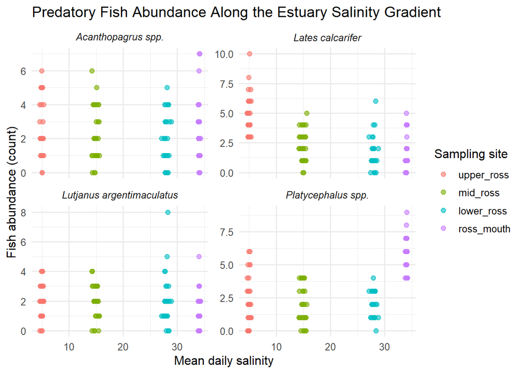

```r
#Abundance-salinity figure
fish_salinity_plot <- plot_data |>
  ggplot(
    aes(
      x = mean_salinity,
      y = count,
      colour = site
    )
  ) +
  geom_point(
    alpha = 0.6,
    size = 2
  ) +
  facet_wrap(
    ~ facet_name,
    labeller = label_parsed,
    scales = "free_y"
  ) +
  labs(
    title = "Predatory Fish Abundance Along the Estuary Salinity Gradient",
    x = "Mean daily salinity",
    y = "Fish abundance (count)",
    colour = "Sampling site"
  ) +
  theme_minimal(base_size = 12)

fish_salinity_plot
```

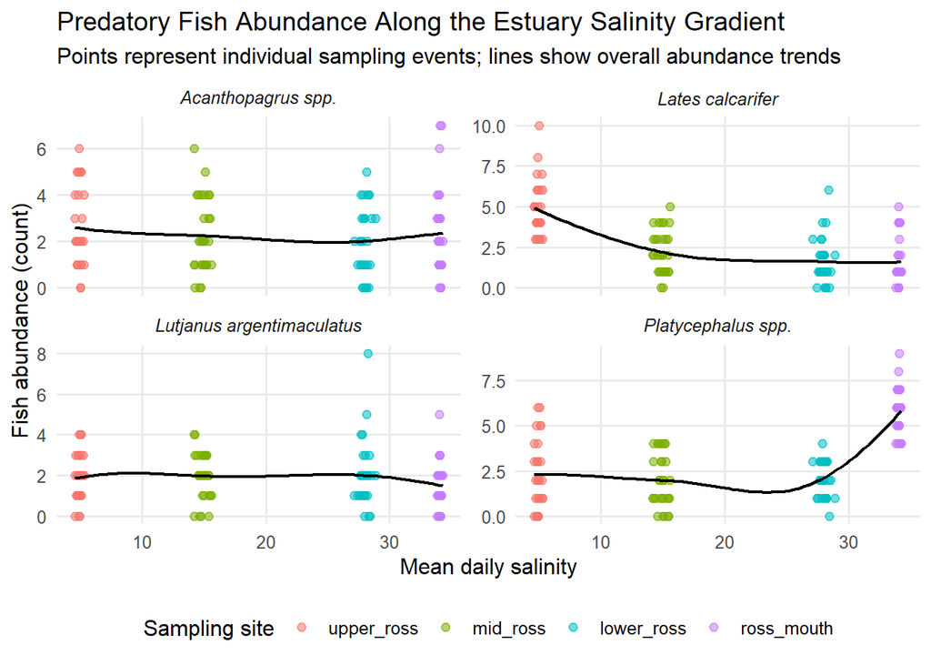

```r
#Add ecological trend line
fish_salinity_plot <- plot_data |>
  ggplot(
    aes(
      x = mean_salinity,
      y = count,
      colour = site
    )
  ) +
  geom_point(
    alpha = 0.55,
    size = 2
  ) +
  geom_smooth(
    aes(group = 1),
    method = "loess",
    se = FALSE,
    colour = "black",
    linewidth = 0.8
  ) +
  facet_wrap(
    ~ facet_name,
    labeller = label_parsed,
    scales = "free_y"
  ) +
  labs(
    title = "Predatory Fish Abundance Along the Estuary Salinity Gradient",
    subtitle = "Points represent individual sampling events; lines show overall abundance trends",
    x = "Mean daily salinity",
    y = "Fish abundance (count)",
    colour = "Sampling site"
  ) +
  theme_minimal(base_size = 12) +
  theme(
    legend.position = "bottom",
    panel.grid.minor = element_blank()
  )

fish_salinity_plot
```

```r
#Save
ggsave(
  filename = here(
    "outputs",
    "workshop2_fish_salinity_gradient.png"
  ),
  plot = fish_salinity_plot,
  width = 9,
  height = 6,
  dpi = 300
)
```

### Interpretation

The final visualisation integrates biological catch data with environmental measurements collected along the estuary. Faceting by species allows species-specific abundance patterns to be compared across the salinity gradient, while inclusion of explicit zero catches ensures that observed absences contribute to the ecological interpretation rather than being omitted from the analysis.

###Troubleshooting During the workflow, all temperature and salinity values initially appeared as missing after joining the biological and environmental datasets. I traced the problem backwards through the pipeline and found that all 11,520 sonde timestamps had been converted to NA because the original timestamps contained hours and minutes but no seconds. Replacing dmy_hms() with the appropriate dmy_hm() parser corrected the timestamps and allowed the datasets to join successfully. This demonstrated the importance of validating intermediate outputs rather than assuming that code has worked simply because it runs without an error.